# Desenvolvendo uma aplicação de Recomendação do Spotify

Resolvi escrever esse texto apenas para tentar explicar melhor como que foi construída a aplicação web que avalia qual música das 50 mais tocadas no Spotify se parece com uma música que seja testada pelo usuário. Esse texto está bastante resumido, pelo fato de que a ideia dele é apenas comentar como foi feito. Disponibilizei o código apenas da parte que calcula a recomendação.

Em linhas gerais tentarei explicar tudo em 4 partes:

- Descrição das ferramentas na aplicação
- Como funciona a API do Spotify
- Como é calculado a semelhança entre as músicas
- O cálculo na prática

# Descrição das ferramentas na aplicação

Eu resolvi fazer essa aplicação utilizando o back-end em Python e o front-end utilizando React. Ambas ferramentas me dão um certo conforto em trabalhar.

O back-end em Python foi uma escolha quase que essencial, pois pude utilizar várias bibliotecas muito boas para quem é cientista de dados, como Pandas, Numpy, Scikitlearn. Em parceria com essas bibliotecas, que foram responsáveis pelos cálculos e estimativas, utilizei o framework Django, que ficou responsável pela criação dos end-points. Neste caso, o back-end havia apenas três end-points: Um para requisitar a música que será comparada, outro para requisitar as 50 musicas mais tocadas atualmente no Spotify, e um último para realizar os cálculos e devolver os resultados. Não utilizei nada de banco de dados nesta aplicação, por não haver interesse em armazenar nenhuma informação, ao menos até este momento.

# Como funciona a API do Spotify

O Spotify disponibiliza um serviço no qual diversas métricas do seu conteúdo são disponibilizados. Com um cadastro e em posse de suas credenciais você tem acesso. Como suporte utilizei a biblioteca Spotipy do Python. Quando coletei dados de uma música, diversas informações são retornados, inclusive características das músicas hospedadas neste aplicativo. Apenas baseado nas métricas por eles geradas, consiste essa aplicação. Utilizei uma transformção, de modo a ficar entre zero e um, isso fácilita em aspecto de interpretção e calculos.

# Como é calculado a semelhança entre as músicas

Primeiramente, eu partir de duas variáveis muito comuns: Peso e Altura. De forma muito fácil gerei um conjunto de dados com 500 observações. Assumindo que peso e altura são grandezas que aderem a uma distribuição normal multivariada, com médias 60kg e 1.66m, respectivamente, e uma matriz de covariância:

$ \left(\begin{array}{cc} 100 & 0.8\\ 0.8 & 0.0025 \end{array}\right) $

```python
import pandas as pd
import numpy as np
import warnings

warnings.filterwarnings('ignore')
```

```python
from scipy.stats import multivariate_normal

df = pd.DataFrame(np.random.multivariate_normal([60, 1.66], [[100, 0.8], [0.8, 0.0025]],500))

df.columns = ["Peso","Altura"]

df.head(5)
```

|  | Peso | Altura |
| --- | --- | --- |
| 0 | 68.106613 | 1.692485 |
| 1 | 72.441020 | 1.730303 |
| 2 | 60.011615 | 1.587162 |
| 3 | 54.436238 | 1.664511 |
| 4 | 57.996547 | 1.606884 |

Dai criei duas variáveis a mais: IMC e Estado. A primeira, é referente a um indicador que pode ser utilizado na avaliação nutricional. A segunda é apenas uma categorização da primeira, subdividindo-a em: Desnutrido, Peso normal e Sobrepeso.

```python
df['IMC'] = df['Peso']/(df['Altura']**2)

df['Estado'] = pd.cut(df['IMC'], [0,18.5,25,np.inf], right=False, labels= ["Desnutrido","Peso normal","Sobrepeso"])
```

```python
df = df.drop(["IMC"],axis=1)
```

Com um gráfico de pontos, pode-se ver claramente que os grupos se separam de forma bem evidênte.

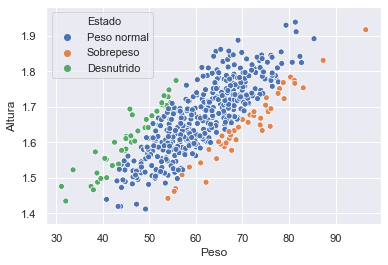

```python
import seaborn as sns; sns.set()
import matplotlib.pyplot as plt

sns.scatterplot(x="Peso", y="Altura",  hue="Estado", data=df)
```

Desta forma vamos supor um novo indivíduo com 1.60m e 68kg. Após transformar os dados de forma que todas as variáveis fiquem entre zero e um, calculei a distância euclidiana deste novo indivíduo em comparação com todos os demais gerados anteriormente. E simplesmente coletei o que mais se aproxima dele.

Como todas as variáveis estão apenas variando entre zero e um, a distância máxima possível é $\sqrt{2}$. Dividindo esta distância por raiz de dois temos uma distância entre zero e um. Utilizei este indicador para avaliar similaridade. Quanto mais próximo de zero mais similar são

```python
from sklearn.preprocessing import MinMaxScaler

scala = MinMaxScaler()

scala.fit(df.drop(['Estado'],axis=1))
df_escalonado = pd.DataFrame(scala.transform(df.drop(['Estado'],axis=1)))
df_escalonado.columns = df.drop(['Estado'],axis=1).columns

df_escalonado.head(5)
```

|  | Peso | Altura |
| --- | --- | --- |
| 0 | 0.565765 | 0.532344 |
| 1 | 0.632071 | 0.604111 |
| 2 | 0.441931 | 0.332470 |
| 3 | 0.356641 | 0.479257 |
| 4 | 0.411105 | 0.369897 |

```python
sujeito = {
    "Peso":[68],
    "Altura":[1.60]
}

sujeito = pd.DataFrame(sujeito)
sujeito
```

|  | Peso | Altura |
| --- | --- | --- |
| 0 | 68 | 1.6 |

```python
minimos = {}
largura = {}

for id,nome in enumerate(df_escalonado.columns):
  minimos[nome] = scala.data_min_[id]
  largura[nome] = scala.data_range_[id]
```

```python
for n in sujeito.columns:
  sujeito[n] = (sujeito[n] - minimos[n])/largura[n]

sujeito
```

|  | Peso | Altura |
| --- | --- | --- |
| 0 | 0.564134 | 0.356833 |

```python
dists = []
for i in range(0,np.shape(df_escalonado)[0]):
    dists.append(np.sqrt(np.sum((df_escalonado.iloc[i,:].values - sujeito.values)**2)))

dists[0:5]
```

```
[0.17551784978475468,
 0.25643995485958593,
 0.1246077822969135,
 0.24091626436460084,
 0.15358504231306622]
```

```python
df.iloc[np.where(dists == np.amin(dists))[0][0],:]
```

```
Peso        68.6366
Altura      1.60748
Estado    Sobrepeso
Name: 257, dtype: object
```

# O cálculo na prática

Primeiramente um objeto foi criado com funções úteis para realizar todo o processo.

Em seguida iniciamos o objeto `Funcoes`. Nesta etapa é feita a requisição de acesso a API. Aqui ficam incluídas as credenciais.

Utilizando o id da música escolhida, tive acesso aos dados que queria. Exclui as variáveis que não me interessava e transformei as únicas duas variáveis que não possuíam domínio entre zero e um.

O mesmo processo foi realizado para requisitar as informações das músicas mais tocadas. Para este caso, o método em questão, primeiramente coleta os id de todas as músicas que pertencem as mais tocadas e em seguida coleta as informações dos áudios em questão. Realizei a mesma transformção feita com a música solicitada na etapa anterior.

De agora em diante fica fácil. Apenas calculei as distâncias euclidianas e verifiquei qual a música do top 50 que mais se aproxima da solicitada.

```python
import spotipy
import spotipy.util as util

from spotipy.oauth2 import SpotifyClientCredentials



class Funcoes:

    def __init__(self):
        self.client_id = '40bac3817c7b4dfab61f7ffff5dea928'
        self.client_secret = '620cef49abbb4284b8af38e7188691a7'
        self.client_credentials_manager = SpotifyClientCredentials(client_id=self.client_id, client_secret=self.client_secret)
        self.sp = spotipy.Spotify(client_credentials_manager=self.client_credentials_manager)

    def get_musica(self,music_id):
        sp = self.sp
        saida = {
            'features':sp.audio_features(music_id),
            'track':sp.track(music_id)
        }
        return(saida)



    def get_playlist_audio_features(self,username, playlist_id):
        sp = self.sp
        offset = 0
        songs = []
        items = []
        ids = []
        while True:
            content = sp.user_playlist_tracks(username, playlist_id, fields=None, limit=100, offset=offset, market=None)
            songs += content['items']
            if content['next'] is not None:
                offset += 100
            else:
                break

        for i in songs:
            ids.append(i['track']['id'])

        index = 0
        audio_features = []
        while index < len(ids):
            try:
                audio_features += sp.audio_features(ids[index:index + 50])
                index += 50
            except:
                pass

        top_null = []
        for i in audio_features:
            if not i is None:
                top_null.append(i)

        return (top_null)
```

```python
funcoes = Funcoes()

musicas = funcoes.get_musica(music_id = "2XU0oxnq2qxCpomAAuJY8K")
musicas = pd.DataFrame(musicas['features'])

links_musica = musicas['uri']

musicas = musicas.drop(['time_signature','key','mode','type','uri','id','track_href','analysis_url','duration_ms'],axis=1)

musicas['loudness'] = (musicas['loudness']+60)/(60)
musicas['tempo'] = (musicas['tempo'] - 25)/200


musicas
```

|  | danceability | energy | loudness | speechiness | acousticness | instrumentalness | liveness | valence | tempo |
| --- | --- | --- | --- | --- | --- | --- | --- | --- | --- |
| 0 | 0.824 | 0.588 | 0.893333 | 0.0924 | 0.692 | 0.000104 | 0.149 | 0.513 | 0.365135 |

```python
top = funcoes.get_playlist_audio_features('renan_bispo',"37i9dQZEVXbMDoHDwVN2tF")
top = pd.DataFrame(top)

top.head(5)
```

|  | danceability | energy | key | loudness | mode | speechiness | acousticness | instrumentalness | liveness | valence | tempo | type | id | uri | track_href | analysis_url | duration_ms | time_signature |
| --- | --- | --- | --- | --- | --- | --- | --- | --- | --- | --- | --- | --- | --- | --- | --- | --- | --- | --- |
| 0 | 0.514 | 0.730 | 1 | -5.934 | 1 | 0.0598 | 0.00146 | 0.000095 | 0.0897 | 0.334 | 171.005 | audio_features | 0VjIjW4GlUZAMYd2vXMi3b | spotify:track:0VjIjW4GlUZAMYd2vXMi3b | https://api.spotify.com/v1/tracks/0VjIjW4GlUZA... | https://api.spotify.com/v1/audio-analysis/0VjI... | 200040 | 4 |
| 1 | 0.830 | 0.490 | 1 | -8.820 | 0 | 0.2090 | 0.28900 | 0.000003 | 0.1130 | 0.845 | 81.604 | audio_features | 466cKvZn1j45IpxDdYZqdA | spotify:track:466cKvZn1j45IpxDdYZqdA | https://api.spotify.com/v1/tracks/466cKvZn1j45... | https://api.spotify.com/v1/audio-analysis/466c... | 247059 | 4 |
| 2 | 0.770 | 0.724 | 8 | -5.484 | 1 | 0.0495 | 0.01670 | 0.010700 | 0.3530 | 0.898 | 121.975 | audio_features | 24Yi9hE78yPEbZ4kxyoXAI | spotify:track:24Yi9hE78yPEbZ4kxyoXAI | https://api.spotify.com/v1/tracks/24Yi9hE78yPE... | https://api.spotify.com/v1/audio-analysis/24Yi... | 176840 | 4 |
| 3 | 0.716 | 0.537 | 0 | -7.648 | 0 | 0.0514 | 0.23300 | 0.000000 | 0.1570 | 0.280 | 129.979 | audio_features | 39Yp9wwQiSRIDOvrVg7mbk | spotify:track:39Yp9wwQiSRIDOvrVg7mbk | https://api.spotify.com/v1/tracks/39Yp9wwQiSRI... | https://api.spotify.com/v1/audio-analysis/39Yp... | 165978 | 4 |
| 4 | 0.726 | 0.431 | 8 | -8.765 | 0 | 0.1350 | 0.73100 | 0.000000 | 0.6960 | 0.348 | 144.026 | audio_features | 7eJMfftS33KTjuF7lTsMCx | spotify:track:7eJMfftS33KTjuF7lTsMCx | https://api.spotify.com/v1/tracks/7eJMfftS33KT... | https://api.spotify.com/v1/audio-analysis/7eJM... | 173333 | 4 |

```python
top = top.drop(['time_signature','key','mode','type','uri','id','track_href','analysis_url','duration_ms'],axis=1)
nomes = top.columns

top['loudness'] = (top['loudness'] + 60)/(60)
top['tempo'] = (top['tempo'] - 25)/200

top.head(5)
```

|  | danceability | energy | loudness | speechiness | acousticness | instrumentalness | liveness | valence | tempo |
| --- | --- | --- | --- | --- | --- | --- | --- | --- | --- |
| 0 | 0.514 | 0.730 | 0.901100 | 0.0598 | 0.00146 | 0.000095 | 0.0897 | 0.334 | 0.730025 |
| 1 | 0.830 | 0.490 | 0.853000 | 0.2090 | 0.28900 | 0.000003 | 0.1130 | 0.845 | 0.283020 |
| 2 | 0.770 | 0.724 | 0.908600 | 0.0495 | 0.01670 | 0.010700 | 0.3530 | 0.898 | 0.484875 |
| 3 | 0.716 | 0.537 | 0.872533 | 0.0514 | 0.23300 | 0.000000 | 0.1570 | 0.280 | 0.524895 |
| 4 | 0.726 | 0.431 | 0.853917 | 0.1350 | 0.73100 | 0.000000 | 0.6960 | 0.348 | 0.595130 |

```python
for id,col in enumerate(top.columns):
    top.rename(columns={col:nomes[id]}, inplace=True)
```

```python
minimos = {}
maximos = {}
largura = {}

saida = []
for id,nome in enumerate(top.columns):
    if nome == "loudness":
        minimos[nome] = -60
        maximos[nome] = 0
        largura[nome] = 60

    elif nome == "tempo":
        minimos[nome] = 25
        maximos[nome] = 225
        largura[nome] = 200

    else:
        minimos[nome] = 0
        maximos[nome] = 1
        largura[nome] = 1
```

```python
dists = []
for i in range(0,np.shape(top)[0]):
    dists.append(np.sqrt(np.sum((top.iloc[i,:].values - musicas.values)**2)))

dists = dists/np.sqrt(2)
```

```python
posicao = np.where(dists == np.amin(dists))[0][0]


parecida = top.iloc[posicao,:]
```

```python
np.where(dists == np.amin(dists))
```

```
(array([8], dtype=int64),)
```

```python
dist = np.absolute(top.iloc[posicao,:].values - musicas.values)

dist
```

```
array([[1.00000000e-03, 5.00000000e-03, 1.66666667e-05, 6.40000000e-03,
        4.00000000e-03, 5.70000000e-05, 2.10000000e-02, 2.70000000e-02,
        2.55000000e-04]])
```

```python
caracteristica = nomes[np.where(dist == np.amin(dist))[1][0]]

caracteristica
```

```
'loudness'
```

```python
dist_parecidas = 1 - dists[posicao]

saida = {
    "parecida":parecida,
    "dist_parecidas": dist_parecidas
}

saida
```

```
{'parecida': danceability        0.825000
 energy              0.593000
 loudness            0.893317
 speechiness         0.098800
 acousticness        0.688000
 instrumentalness    0.000161
 liveness            0.170000
 valence             0.540000
 tempo               0.365390
 Name: 8, dtype: float64,
 'dist_parecidas': 0.9749697328042849}
```